# Part I - Customer Exploration From "Ford Go-Bike"

## Introduction

**This is a dataset from the commuter bike company “Ford G-Bike”. It covers the daily usage from Feb-Mar 2019 in the San Fransico area.**

## Preliminary Wrangling

```python
import pandas as pd

import numpy as np
import matplotlib.pyplot as plt
import seaborn as sns
from datetime import datetime
import math

# suppress warnings from final output
import warnings
warnings.simplefilter("ignore")
```

## Importing the data

```python
data = pd.read_csv('201902-fordgobike-tripdata.csv')
df = data.copy()
df.head()
```

|  | duration_sec | start_time | end_time | start_station_id | start_station_name | start_station_latitude | start_station_longitude | end_station_id | end_station_name | end_station_latitude | end_station_longitude | bike_id | user_type | member_birth_year | member_gender | bike_share_for_all_trip |
| --- | --- | --- | --- | --- | --- | --- | --- | --- | --- | --- | --- | --- | --- | --- | --- | --- |
| 0 | 52185 | 2019-02-28 17:32:10.1450 | 2019-03-01 08:01:55.9750 | 21.0 | Montgomery St BART Station (Market St at 2nd St) | 37.789625 | -122.400811 | 13.0 | Commercial St at Montgomery St | 37.794231 | -122.402923 | 4902 | Customer | 1984.0 | Male | No |
| 1 | 42521 | 2019-02-28 18:53:21.7890 | 2019-03-01 06:42:03.0560 | 23.0 | The Embarcadero at Steuart St | 37.791464 | -122.391034 | 81.0 | Berry St at 4th St | 37.775880 | -122.393170 | 2535 | Customer | NaN | NaN | No |
| 2 | 61854 | 2019-02-28 12:13:13.2180 | 2019-03-01 05:24:08.1460 | 86.0 | Market St at Dolores St | 37.769305 | -122.426826 | 3.0 | Powell St BART Station (Market St at 4th St) | 37.786375 | -122.404904 | 5905 | Customer | 1972.0 | Male | No |
| 3 | 36490 | 2019-02-28 17:54:26.0100 | 2019-03-01 04:02:36.8420 | 375.0 | Grove St at Masonic Ave | 37.774836 | -122.446546 | 70.0 | Central Ave at Fell St | 37.773311 | -122.444293 | 6638 | Subscriber | 1989.0 | Other | No |
| 4 | 1585 | 2019-02-28 23:54:18.5490 | 2019-03-01 00:20:44.0740 | 7.0 | Frank H Ogawa Plaza | 37.804562 | -122.271738 | 222.0 | 10th Ave at E 15th St | 37.792714 | -122.248780 | 4898 | Subscriber | 1974.0 | Male | Yes |

### What is the structure of your dataset?

The dataset contains the following columns

duration_sec - how long the bikes were used for

start_time – The date and time of when the user started the ride

end_time – The date and time of when the user ended the ride

start_station_id – The bike “station” id where the journey began

start_station_name - The bike “station” name where the journey began

start_station_latitude - The bike “station” latitude co-ordinates where the journey began

start_station_longitude - The bike “station” longitude co-ordinates where the journey began

end_station_id – The bike “station” id where the journey ended

end_station_name - The bike “station” name where the journey ended

end_station_latitude - The bike “station” latitude co-ordinates where the journey ended

end_station_longitude - The bike “station” longitude co-ordinates where the journey ended

bike_id – The unique ID for each bike

user_type – “Customer” casual user and “Subscriber” regular user

member_birth_year – The supplied year of birth of the user

member_gender – The supplied gender of the user

bike_share_for_all_trip – Trips for multiple users under one account

### What is/are the main feature(s) of interest in your dataset?

**I’m curious to look into user behavior. The bio data in particular, who are customers and how are they using the bikes?**

### What features in the dataset do you think will help support your investigation into your feature(s) of interest?

**How long the bikes are being used, this can be extracted from duration_sec start/end time and the start/end stations.**

**Busiest days, this can be pulled from "start_time"**

**Bio data can be pulled from age groups and gender, where available.**

**The kind of distances travelled, this will require the latitude & longitude**

```python
df.info()
```

```
<class 'pandas.core.frame.DataFrame'>
RangeIndex: 183412 entries, 0 to 183411
Data columns (total 16 columns):
 #   Column                   Non-Null Count   Dtype
---  ------                   --------------   -----
 0   duration_sec             183412 non-null  int64
 1   start_time               183412 non-null  object
 2   end_time                 183412 non-null  object
 3   start_station_id         183215 non-null  float64
 4   start_station_name       183215 non-null  object
 5   start_station_latitude   183412 non-null  float64
 6   start_station_longitude  183412 non-null  float64
 7   end_station_id           183215 non-null  float64
 8   end_station_name         183215 non-null  object
 9   end_station_latitude     183412 non-null  float64
 10  end_station_longitude    183412 non-null  float64
 11  bike_id                  183412 non-null  int64
 12  user_type                183412 non-null  object
 13  member_birth_year        175147 non-null  float64
 14  member_gender            175147 non-null  object
 15  bike_share_for_all_trip  183412 non-null  object
dtypes: float64(7), int64(2), object(7)
memory usage: 22.4+ MB
```

```python
df.shape
```

```
(183412, 16)
```

### Stats

```python
df.describe()
```

|  | duration_sec | start_station_id | start_station_latitude | start_station_longitude | end_station_id | end_station_latitude | end_station_longitude | bike_id | member_birth_year |
| --- | --- | --- | --- | --- | --- | --- | --- | --- | --- |
| count | 183412.000000 | 183215.000000 | 183412.000000 | 183412.000000 | 183215.000000 | 183412.000000 | 183412.000000 | 183412.000000 | 175147.000000 |
| mean | 726.078435 | 138.590427 | 37.771223 | -122.352664 | 136.249123 | 37.771427 | -122.352250 | 4472.906375 | 1984.806437 |
| std | 1794.389780 | 111.778864 | 0.099581 | 0.117097 | 111.515131 | 0.099490 | 0.116673 | 1664.383394 | 10.116689 |
| min | 61.000000 | 3.000000 | 37.317298 | -122.453704 | 3.000000 | 37.317298 | -122.453704 | 11.000000 | 1878.000000 |
| 25% | 325.000000 | 47.000000 | 37.770083 | -122.412408 | 44.000000 | 37.770407 | -122.411726 | 3777.000000 | 1980.000000 |
| 50% | 514.000000 | 104.000000 | 37.780760 | -122.398285 | 100.000000 | 37.781010 | -122.398279 | 4958.000000 | 1987.000000 |
| 75% | 796.000000 | 239.000000 | 37.797280 | -122.286533 | 235.000000 | 37.797320 | -122.288045 | 5502.000000 | 1992.000000 |
| max | 85444.000000 | 398.000000 | 37.880222 | -121.874119 | 398.000000 | 37.880222 | -121.874119 | 6645.000000 | 2001.000000 |

```python
df.isna().sum()
```

```
duration_sec                  0
start_time                    0
end_time                      0
start_station_id            197
start_station_name          197
start_station_latitude        0
start_station_longitude       0
end_station_id              197
end_station_name            197
end_station_latitude          0
end_station_longitude         0
bike_id                       0
user_type                     0
member_birth_year          8265
member_gender              8265
bike_share_for_all_trip       0
dtype: int64
```

**There are 197 missing values in the start/end stations and 8265 missing member_gender/member_birth_year values. I’m going to drop the 197 missing values as it won’t be needed for my analysis. But I will keep the 8265 missing genders but replace them with ‘other’ in order to retain the number of people who use the bikes.**

### Dropping the NaN from the Start Station ID and flling in the missing member genders

```python
df1 = df.dropna(subset=['start_station_id']).copy()

df1['member_gender'].fillna('Other', inplace=True)

df1.isna().sum()
```

```
duration_sec                  0
start_time                    0
end_time                      0
start_station_id              0
start_station_name            0
start_station_latitude        0
start_station_longitude       0
end_station_id                0
end_station_name              0
end_station_latitude          0
end_station_longitude         0
bike_id                       0
user_type                     0
member_birth_year          8263
member_gender                 0
bike_share_for_all_trip       0
dtype: int64
```

**To give more of a breakdown of the usage, I’ll extract the day/time information from the ‘start_time’ and ‘end_time’ and convert them into the appropriate data type.**

```python
# Converting start_time and end_time to datetime format
df1['start_time'] = pd.to_datetime(df1['start_time'])
df1['end_time'] = pd.to_datetime(df1['end_time'])

# Extracting the date, time (hour and minute), and day of the week
df1['start_date'] = df1['start_time'].dt.date
df1['end_date'] = df1['end_time'].dt.date

# Create a column for the pickup/dropoff time
df1['pickup_time'] = df1['start_time'].dt.strftime('%H:%M')
df1['dropoff_time'] = df1['end_time'].dt.strftime('%H:%M')


# Creating a column for the pickup/dropoff day
df1['pickup_day'] = df1['start_time'].dt.day_name()
df1['dropoff_day'] = df1['end_time'].dt.day_name()



# Converting start_date and end_date to datetime format
df1['start_date'] = pd.to_datetime(df1['start_date'])
df1['end_date'] = pd.to_datetime(df1['end_date'])
df2 = df1.drop(columns=['start_time','end_time']).copy()

df2.head()
```

|  | duration_sec | start_station_id | start_station_name | start_station_latitude | start_station_longitude | end_station_id | end_station_name | end_station_latitude | end_station_longitude | bike_id | user_type | member_birth_year | member_gender | bike_share_for_all_trip | start_date | end_date | pickup_time | dropoff_time | pickup_day | dropoff_day |
| --- | --- | --- | --- | --- | --- | --- | --- | --- | --- | --- | --- | --- | --- | --- | --- | --- | --- | --- | --- | --- |
| 0 | 52185 | 21.0 | Montgomery St BART Station (Market St at 2nd St) | 37.789625 | -122.400811 | 13.0 | Commercial St at Montgomery St | 37.794231 | -122.402923 | 4902 | Customer | 1984.0 | Male | No | 2019-02-28 | 2019-03-01 | 17:32 | 08:01 | Thursday | Friday |
| 1 | 42521 | 23.0 | The Embarcadero at Steuart St | 37.791464 | -122.391034 | 81.0 | Berry St at 4th St | 37.775880 | -122.393170 | 2535 | Customer | NaN | Other | No | 2019-02-28 | 2019-03-01 | 18:53 | 06:42 | Thursday | Friday |
| 2 | 61854 | 86.0 | Market St at Dolores St | 37.769305 | -122.426826 | 3.0 | Powell St BART Station (Market St at 4th St) | 37.786375 | -122.404904 | 5905 | Customer | 1972.0 | Male | No | 2019-02-28 | 2019-03-01 | 12:13 | 05:24 | Thursday | Friday |
| 3 | 36490 | 375.0 | Grove St at Masonic Ave | 37.774836 | -122.446546 | 70.0 | Central Ave at Fell St | 37.773311 | -122.444293 | 6638 | Subscriber | 1989.0 | Other | No | 2019-02-28 | 2019-03-01 | 17:54 | 04:02 | Thursday | Friday |
| 4 | 1585 | 7.0 | Frank H Ogawa Plaza | 37.804562 | -122.271738 | 222.0 | 10th Ave at E 15th St | 37.792714 | -122.248780 | 4898 | Subscriber | 1974.0 | Male | Yes | 2019-02-28 | 2019-03-01 | 23:54 | 00:20 | Thursday | Friday |

**Using the provided latitude and longitude, and incorporating the popular Haversine function, I’ve added two columns that measure the distance (KM and Miles) travelled for each journey.**

```python
# Calculating the distance travelled in KM and M

# Define the haversine function
def haversine(lat1, lon1, lat2, lon2, unit='km'):
    # Radius of the Earth
    R = 6371.0  # in kilometers. Use 3956 for miles.
    if unit == 'miles':
        R = 3956.0

    # Convert latitude and longitude from degrees to radians
    lat1 = math.radians(lat1)
    lon1 = math.radians(lon1)
    lat2 = math.radians(lat2)
    lon2 = math.radians(lon2)

    # Compute differences
    dlon = lon2 - lon1
    dlat = lat2 - lat1

    # Haversine formula
    a = math.sin(dlat / 2)**2 + math.cos(lat1) * math.cos(lat2) * math.sin(dlon / 2)**2
    c = 2 * math.atan2(math.sqrt(a), math.sqrt(1 - a))

    # Distance
    distance = R * c

    return distance


df2['distance_km'] = df2.apply(lambda row: haversine(row['start_station_latitude'], row['start_station_longitude'], row['end_station_latitude'], row['end_station_longitude'], unit='km'), axis=1)
df2['distance_miles'] = df2.apply(lambda row: haversine(row['start_station_latitude'], row['start_station_longitude'], row['end_station_latitude'], row['end_station_longitude'], unit='miles'), axis=1)


df2.head()
```

|  | duration_sec | start_station_id | start_station_name | start_station_latitude | start_station_longitude | end_station_id | end_station_name | end_station_latitude | end_station_longitude | bike_id | ... | member_gender | bike_share_for_all_trip | start_date | end_date | pickup_time | dropoff_time | pickup_day | dropoff_day | distance_km | distance_miles |
| --- | --- | --- | --- | --- | --- | --- | --- | --- | --- | --- | --- | --- | --- | --- | --- | --- | --- | --- | --- | --- | --- |
| 0 | 52185 | 21.0 | Montgomery St BART Station (Market St at 2nd St) | 37.789625 | -122.400811 | 13.0 | Commercial St at Montgomery St | 37.794231 | -122.402923 | 4902 | ... | Male | No | 2019-02-28 | 2019-03-01 | 17:32 | 08:01 | Thursday | Friday | 0.544709 | 0.338231 |
| 1 | 42521 | 23.0 | The Embarcadero at Steuart St | 37.791464 | -122.391034 | 81.0 | Berry St at 4th St | 37.775880 | -122.393170 | 2535 | ... | Other | No | 2019-02-28 | 2019-03-01 | 18:53 | 06:42 | Thursday | Friday | 1.742999 | 1.082295 |
| 2 | 61854 | 86.0 | Market St at Dolores St | 37.769305 | -122.426826 | 3.0 | Powell St BART Station (Market St at 4th St) | 37.786375 | -122.404904 | 5905 | ... | Male | No | 2019-02-28 | 2019-03-01 | 12:13 | 05:24 | Thursday | Friday | 2.704545 | 1.679357 |
| 3 | 36490 | 375.0 | Grove St at Masonic Ave | 37.774836 | -122.446546 | 70.0 | Central Ave at Fell St | 37.773311 | -122.444293 | 6638 | ... | Other | No | 2019-02-28 | 2019-03-01 | 17:54 | 04:02 | Thursday | Friday | 0.260739 | 0.161903 |
| 4 | 1585 | 7.0 | Frank H Ogawa Plaza | 37.804562 | -122.271738 | 222.0 | 10th Ave at E 15th St | 37.792714 | -122.248780 | 4898 | ... | Male | Yes | 2019-02-28 | 2019-03-01 | 23:54 | 00:20 | Thursday | Friday | 2.409301 | 1.496028 |

5 rows × 22 columns

## Univariate Exploration

### Looking at the year of birth distribution

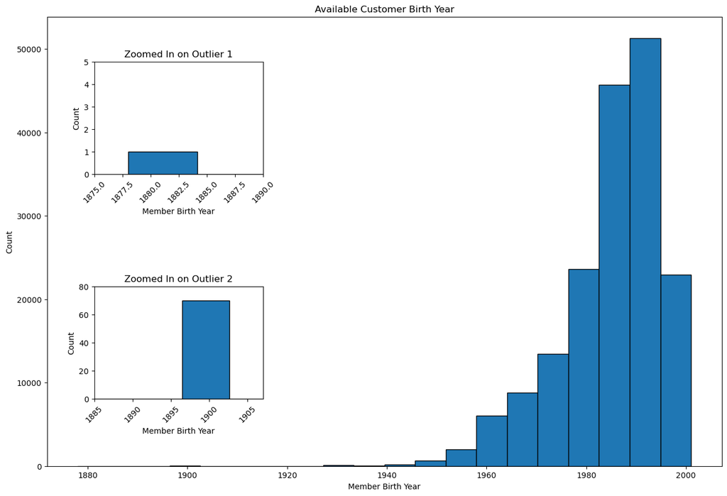

```
''
```

```python
fig = plt.figure(figsize=(12, 8))

# Larger figure axes
axes1 = fig.add_axes([0, 0, 1, 1])
axes1.hist(df2['member_birth_year'], bins=20, edgecolor='black')
axes1.set_xlabel('Member Birth Year')
axes1.set_ylabel('Count')
axes1.set_title('Available Customer Birth Year')

# Insert smaller figure axes [0.6, 0.5, 0.4, 0.4]
axes2 = fig.add_axes([0.07, 0.65, 0.25, 0.25])  # Adjust the position and size as needed
axes2.hist(df2['member_birth_year'], bins=20, edgecolor='black')
axes2.set_xlim(1875, 1890)  # Adjust the x-axis limits for zooming in
axes2.set_ylim(0, 5)  # Adjust the y-axis limits for zooming in
axes2.set_xlabel('Member Birth Year')
axes2.set_ylabel('Count')
axes2.set_title('Zoomed In on Outlier 1')
plt.xticks(rotation=45)



# Insert smaller figure axes [0.5, 0.5, 0.4, 0.4]
axes3 = fig.add_axes([0.07, 0.15, 0.25, 0.25])  # Adjust the position and size as needed
axes3.hist(df2['member_birth_year'], bins=20, edgecolor='black')
axes3.set_xlim(1885, 1907)  # Adjust the x-axis limits for zooming in
axes3.set_ylim(0, 80)  # Adjust the y-axis limits for zooming in
axes3.set_xlabel('Member Birth Year')
axes3.set_ylabel('Count')
axes3.set_title('Zoomed In on Outlier 2')
plt.xticks(rotation=45)

plt.show()
;
```

### Discuss the distribution(s) of your variable(s) of interest. Were there any unusual points? Did you need to perform any transformations?

**In this plot, we can see how the ‘member_birth_year’, both extreme and missing values, has impacted the approximated customers ages.**

### Of the features you investigated, were there any unusual distributions? Did you perform any operations on the data to tidy, adjust, or change the form of the data? If so, why did you do this?

**As the data has been skewed, I’ll use the year that the data was collected, 2019, and calculate, using the ‘member_birth_year’, to get the approximate age. Then drop the 'member_birth_year' column and for the missing ages, I'll use the mean age. Whilst not perfect, it should give a better idea about the ages of the customers**

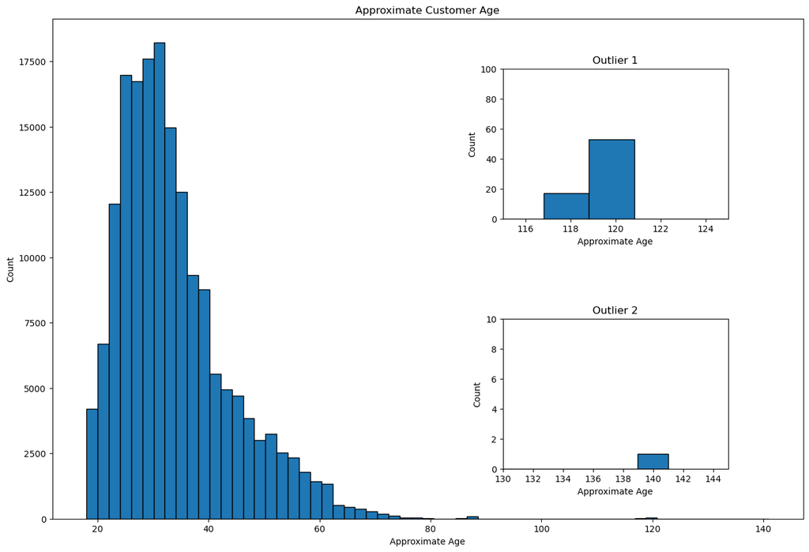

```
''
```

```python
# Creating the approx age column
current_year = 2019
df2['approximate_age'] = current_year -df2['member_birth_year']
df2.loc[df2['member_birth_year'].isna(), 'approximate_age'] = pd.NA


# Create blank canvas
fig = plt.figure(figsize=(12, 8))

# Larger figure axes
axes1 = fig.add_axes([0, 0, 1, 1])
axes1.hist(df2['approximate_age'].dropna(), bins=61, edgecolor='black')
axes1.set_xlabel('Approximate Age')
axes1.set_ylabel('Count')
axes1.set_title('Approximate Customer Age')
axes1.grid(False)

# Insert smaller figure axes
axes2 = fig.add_axes([0.6, 0.6, 0.3, 0.3])  # Adjust the position and size as needed
axes2.hist(df2['approximate_age'].dropna(), bins=61, edgecolor='black')
axes2.set_xlim(115, 125)  # Adjust the x-axis limits for zooming in
axes2.set_ylim(0, 100)  # Adjust the y-axis limits for zooming in
axes2.set_xlabel('Approximate Age')
axes2.set_ylabel('Count')
axes2.set_title('Outlier 1')

# Insert smaller figure axes
axes3 = fig.add_axes([0.6, 0.1, 0.3, 0.3])  # Adjust the position and size as needed
axes3.hist(df2['approximate_age'].dropna(), bins=61, edgecolor='black')
axes3.set_xlim(130, 145)  # Adjust the x-axis limits for zooming in
axes3.set_ylim(0, 10)  # Adjust the y-axis limits for zooming in
axes3.set_xlabel('Approximate Age')
axes3.set_ylabel('Count')
axes3.set_title('Outlier 2')

plt.show()
;
```

### Replacing the missing ages with the mean age

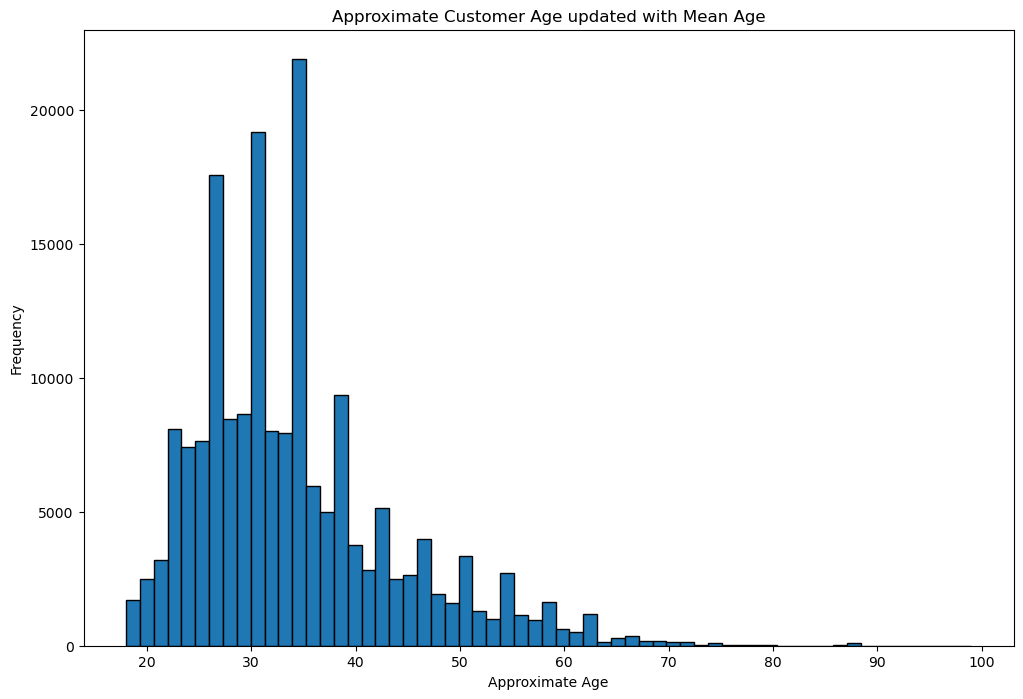

```
''
```

```python
mean_age = df2['approximate_age'][df2['approximate_age'] <= 100].mean()
df2['approximate_age'] = df2['approximate_age'].apply(lambda x: mean_age if pd.isna(x) or x > 100 else x)


# Plotting the histogram
plt.figure(figsize=(12, 8))

# Step 3: Create a histogram with 61 bins
plt.hist(df2['approximate_age'], bins=61, edgecolor='black')
plt.xlabel('Approximate Age')
plt.ylabel('Frequency')
plt.title('Approximate Customer Age updated with Mean Age')
plt.show()
;
```

**I think that this is a clearer view of the customers ages even though some, potentially, extreme values still exist.**

**Unsurprisingly, most of the ages seemed to be centered around the average working/ regular income ages of 25-40**

### User Types

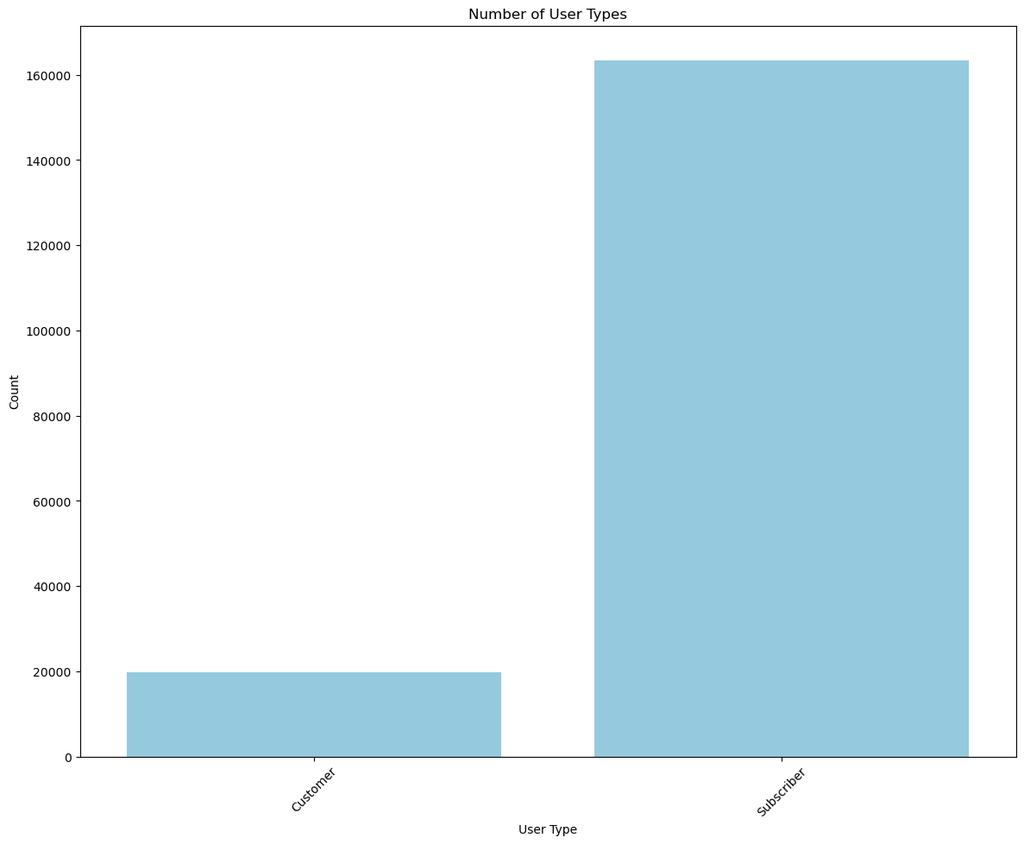

```
''
```

```python
# Creating a countplot
plt.figure(figsize=(14, 11))
sns.countplot(x='user_type',  data=df2, color='skyblue')
plt.title('Number of User Types')
plt.xlabel('User Type')
plt.ylabel('Count')
plt.xticks(rotation =45)
plt.show()
;
```

**This first countplot, shows the kind of news that I’m sure the business would be happy to see. An overwhelming amount of customers are regular subscribers.**

**According to biketoeverything.com:** https://biketoeverything.com/2018/06/12/complete-san-francisco-bikeshare-review/ **the subscription price is 10 dollars per day, 15 dollars per month or 149 dollars p.a.**

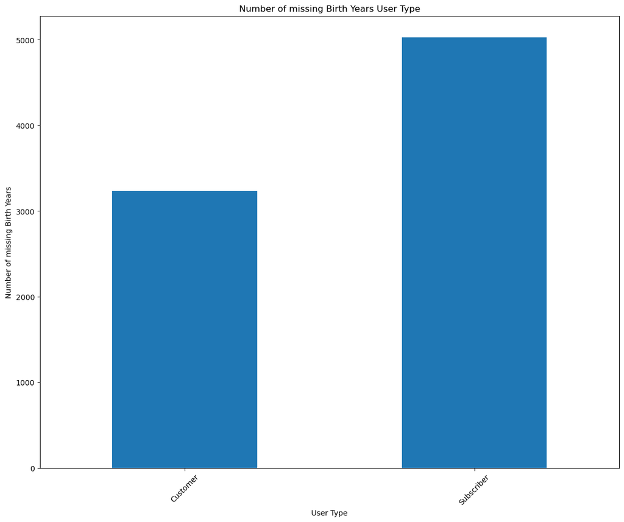

```
''
```

```python
# Filter to only include rows where member_birth_year is NaN
nan_birth_year = df2[df2['member_birth_year'].isna()]

# Group by user_type and member_gender and count occurrences
nan_counts = df2[df2['member_birth_year'].isna()].groupby(['user_type', 'member_gender']).size().unstack()

# dropping birth year
df2.drop(columns=['member_birth_year'],inplace=True)

# Plotting the NaN counts
plt.figure(figsize=(14,11))

ax = nan_counts.plot(kind='bar', stacked=True, figsize=(14,11))

ax.set_ylabel('Number of missing Birth Years')
ax.set_xlabel('User Type')
ax.set_title('Number of missing Birth Years User Type')
ax.legend().set_visible(False)
plt.xticks(rotation=45)
plt.show()

;
```

**This is quite interesting, over 5000 subscribers have chosen not provide their birth years. Further market research could be useful here.**

### Nunber of customers by available Gender

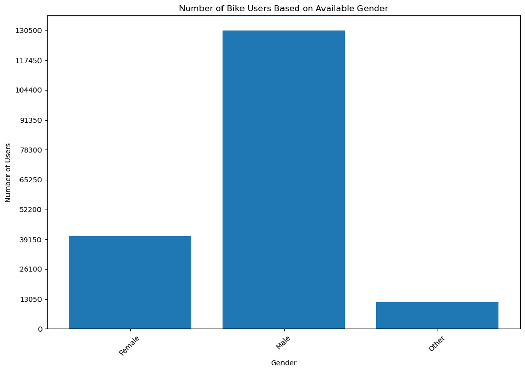

```
''
```

```python
# Agg the gender
gender_counts = df2.groupby('member_gender')['bike_id'].count()


plt.figure(figsize=(12,8))

plt.bar(gender_counts.index, gender_counts.values)
plt.ylabel('Number of Users')
plt.xlabel('Gender')
plt.xticks(rotation=45)
plt.title('Number of Bike Users Based on Available Gender')

# Adding y-ticks
max_y = gender_counts.max()
step = max_y // 10
plt.yticks(range(0, max_y + step, step))


plt.show()

;
```

**In this plot we’ll take a look at the number of supplied genders. We can clearly see that the overwhelming total lies with Male riders.**

### Looking into the daily usage

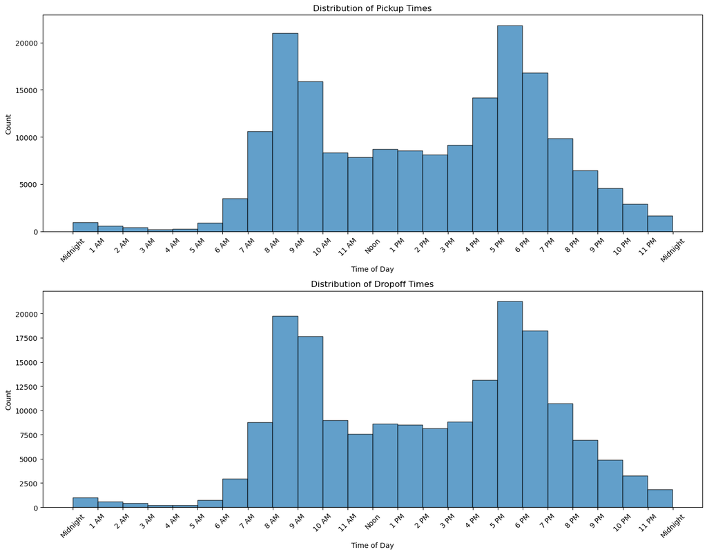

```
''
```

```python
# Extracting the day / times
tods = df2[['bike_id','pickup_day','pickup_time', 'dropoff_day','dropoff_time']].copy()

# Converting the times to the correct format
tods['pickup_time'] = pd.to_datetime(tods['pickup_time'], format='%H:%M').dt.time
tods['dropoff_time'] = pd.to_datetime(tods['dropoff_time'], format='%H:%M').dt.time

plt.figure(figsize=(14, 11))

# Plotting pickup times
plt.subplot(2, 1, 1)
tods['pickup_minutes'] = tods['pickup_time'].apply(lambda x: x.hour * 60 + x.minute)
plt.hist(tods['pickup_minutes'], bins=24, edgecolor='black', alpha=0.7)
plt.xlabel('Time of Day')
plt.ylabel('Count')
plt.title('Distribution of Pickup Times')
plt.grid(False)
plt.xticks(range(0, 1441, 60), ['Midnight', '1 AM', '2 AM', '3 AM', '4 AM', '5 AM', '6 AM', '7 AM', '8 AM', '9 AM', '10 AM', '11 AM', 'Noon', '1 PM', '2 PM', '3 PM', '4 PM', '5 PM', '6 PM', '7 PM', '8 PM', '9 PM', '10 PM', '11 PM', 'Midnight'], rotation=45)
plt.tight_layout()

# Plotting dropoff times
plt.subplot(2, 1, 2)
tods['dropoff_minutes'] = tods['dropoff_time'].apply(lambda x: x.hour * 60 + x.minute)
plt.hist(tods['dropoff_minutes'], bins=24, edgecolor='black', alpha=0.7)
plt.xlabel('Time of Day')
plt.ylabel('Count')
plt.title('Distribution of Dropoff Times')
plt.grid(False)
plt.xticks(range(0, 1441, 60), ['Midnight', '1 AM', '2 AM', '3 AM', '4 AM', '5 AM', '6 AM', '7 AM', '8 AM', '9 AM', '10 AM', '11 AM', 'Noon', '1 PM', '2 PM', '3 PM', '4 PM', '5 PM', '6 PM', '7 PM', '8 PM', '9 PM', '10 PM', '11 PM', 'Midnight'], rotation=45)
plt.tight_layout()

plt.show()

;
```

**These plots are looking at the pickup/dropoff times during a day. While they do look very similar, upon closer inspection, we can some clear differences.**

**Collection times increases significantly from 6am until 10am. This makes sense because these are usually rush periods, the drops (most people are at work) until 4pm where we enter the afternoon rush hour.**

**However, we do have some similar numbers. The 8am-9am pickup/dropoff times are almost the same, as they are from 5pm-6pm. This could suggest that these journeys were relatively short (up to an hour), something I’ll look at later.**

## Bivariate Exploration

### Looking deeper into the customers, gender and age distribution

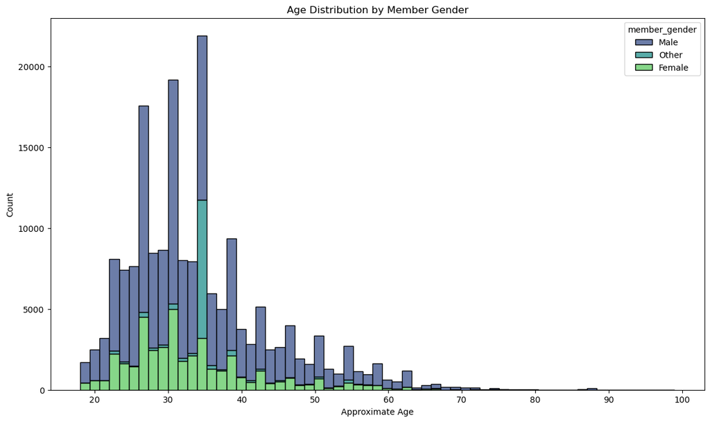

```
''
```

```python
# Plotting using seaborn
plt.figure(figsize=(14, 8))
sns.histplot(data=df2, x='approximate_age', hue='member_gender', multiple='stack', palette='viridis', bins=61)



# Adding titles and labels
plt.title('Age Distribution by Member Gender')
plt.xlabel('Approximate Age')
plt.ylabel('Count')

# Display the plot
plt.show()
;
```

**While there are more male riders than female, the age distribution is very similar**

### Looking into the average distance travelled

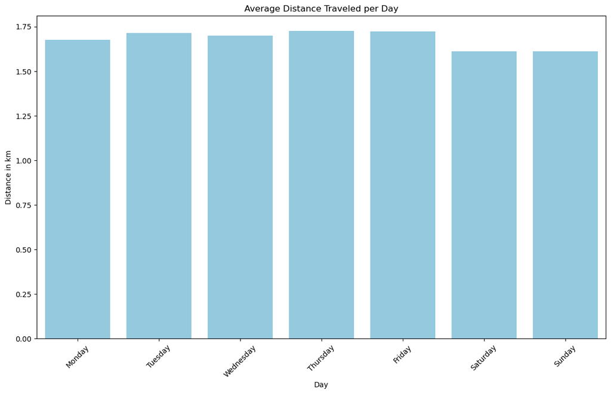

```
''
```

```python
# Extracting the pickup day and distancce travelled
days_travelled = df2[['pickup_day','distance_km']].copy()


# Plotting using seaborn
plt.figure(figsize=(14, 8))

# Creating the weekday list in order
days_order = ['Monday', 'Tuesday', 'Wednesday', 'Thursday', 'Friday', 'Saturday', 'Sunday']
days_travelled['pickup_day'] = pd.Categorical(days_travelled['pickup_day'], categories=days_order, ordered=True)

# Pulling the daily average distance in KM
aver_distance_per_day = days_travelled.groupby('pickup_day', observed=True)['distance_km'].mean().reset_index()



# Bar Plot
#plt.subplot(2, 1, 1)
sns.barplot(x='pickup_day', y='distance_km', data=aver_distance_per_day, color='skyblue')
plt.title('Average Distance Traveled per Day')
plt.xlabel('Day')
plt.ylabel('Distance in km')
plt.xticks(rotation=45)

plt.show()
;
```

**In this plot, we’re looking at the average distance travelled on any given day. Unsurprisingly, there is a drop off at the weekend, but not significantly, this could suggest that customers are taking advantage of, potentially, quieter roads**

### Looking into the max distance travelled per day

**I wanted to look into this, because I was hoping to find some insight into how far people travel with these bikes, now the data shows that, apparently, around 70km had been travelled in a single day. This could be correct, but it’s worth looking into further.**

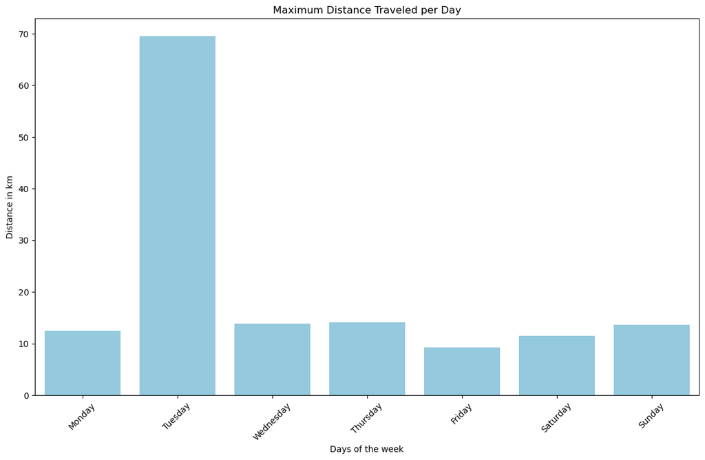

```
''
```

```python
plt.figure(figsize=(14, 8))


# Pulling the max distance travelled in any given day
aver_distance_per_day = days_travelled.groupby('pickup_day', observed=True)['distance_km'].max().reset_index()




sns.barplot(x='pickup_day', y='distance_km', data=aver_distance_per_day, color='skyblue')
plt.title('Maximum Distance Traveled per Day')
plt.xlabel('Days of the week')
plt.ylabel('Distance in km')
plt.xticks(rotation=45)

plt.show()
;
```

### Investigating the travel time vs the distance travelled

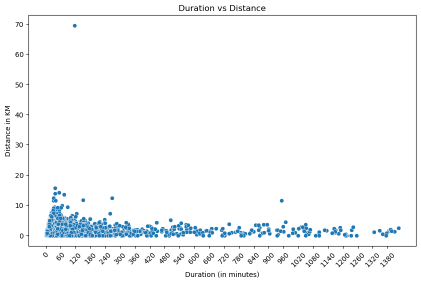

```
''
```

```python
# Using the duration and distance
travel_time = df2[['duration_sec','distance_km']].copy()

# converting secons into minutes
travel_time['duration_min'] = travel_time['duration_sec'] / 60.0

# Define the xticks with a range and a step size for better granularity
xticks = np.arange(0, travel_time['duration_min'].max() + 1, 60)

plt.figure(figsize=(10, 6))
sns.scatterplot(data=travel_time, x='duration_min', y='distance_km')
#sns.scatterplot(data=travel_time, x='duration_min', y='distance_miles', label='Distance (miles)')
plt.title('Duration vs Distance')
plt.xlabel('Duration (in minutes)')

plt.ylabel('Distance in KM')
plt.xticks(xticks)
plt.xticks(rotation = 45)



plt.show()

;
```

### Talk about some of the relationships you observed in this part of the investigation. How did the feature(s) of interest vary with other features in the dataset?

**Using this scatterplot I wanted to look into any correlation between the time vs the distance travelled. This has raised more questions, the customer who travelled around 70km, not only travelled a great distance in one day on a commuter bike, but managed to do it in around 2hrs.**

### Did you observe any interesting relationships between the other features (not the main feature(s) of interest)?

**According to “Bike to Everything” https://biketoeverything.com/2018/06/12/complete-san-francisco-bikeshare-review/ The average bike weight (sold to consumers) is around 22kg (49lbs) compared to the average road bike weight is 8.32kg (18.34lbs) The lowest bike weight used by pro bike racers is around 6.5kg (14.3lbs). Again, it is possible, perhaps a pro rider took a consumer bike out for a day. But without speaking to the customer, I can only speculate.**

## Multivariate Exploration

### Looking at the top 10 busiest start stations

#### Start Stations

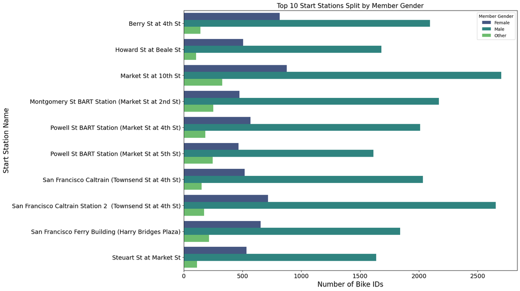

```python
# Aggregate the data
start_station_gender_counts = df2.groupby(['start_station_name', 'member_gender']).size().reset_index(name='count')

# Get the top 10 stations by total bike count
top_start_stations = start_station_gender_counts.groupby('start_station_name')['count'].sum().nlargest(10).index

# Filter the original data to include only the top 10 stations
top_start_station_data = start_station_gender_counts[start_station_gender_counts['start_station_name'].isin(top_start_stations)]

# Plotting using seaborn
plt.figure(figsize=(14, 11))
sns.barplot(x='count', y='start_station_name', hue='member_gender', data=top_start_station_data, palette='viridis')
plt.yticks(fontsize=14)
plt.xticks(fontsize=14)
plt.title('Top 10 Start Stations Split by Member Gender', fontsize=15)
plt.xlabel('Number of Bike IDs', fontsize=16)
plt.ylabel('Start Station Name', fontsize=16)
plt.legend(title='Member Gender')
plt.show();
```

#### End Stations

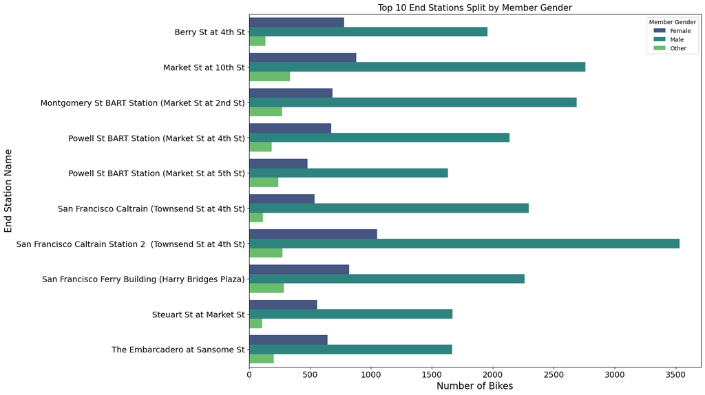

```python
# Aggregate the data
station_gender_counts2 = df2.groupby(['end_station_name', 'member_gender']).size().reset_index(name='count')

# Get the top 10 stations by total bike count
top_end_stations = station_gender_counts2.groupby('end_station_name')['count'].sum().nlargest(10).index

# Filter the original data to include only the top 10 stations
top_end_station_data = station_gender_counts2[station_gender_counts2['end_station_name'].isin(top_end_stations)]

# Plotting using seaborn
plt.figure(figsize=(14, 11))
sns.barplot(x='count', y='end_station_name', hue='member_gender', data=top_end_station_data, palette='viridis', linewidth=0)
plt.yticks(fontsize=14)
plt.xticks(fontsize=14)
plt.title('Top 10 End Stations Split by Member Gender', fontsize=15)
plt.xlabel('Number of Bikes', fontsize=16)
plt.ylabel('End Station Name', fontsize=16)
plt.legend(title='Member Gender')



plt.show();
```

**It would be interesting to see if this remains consistent throughout the year**

### Breaking down the daily distance by gender

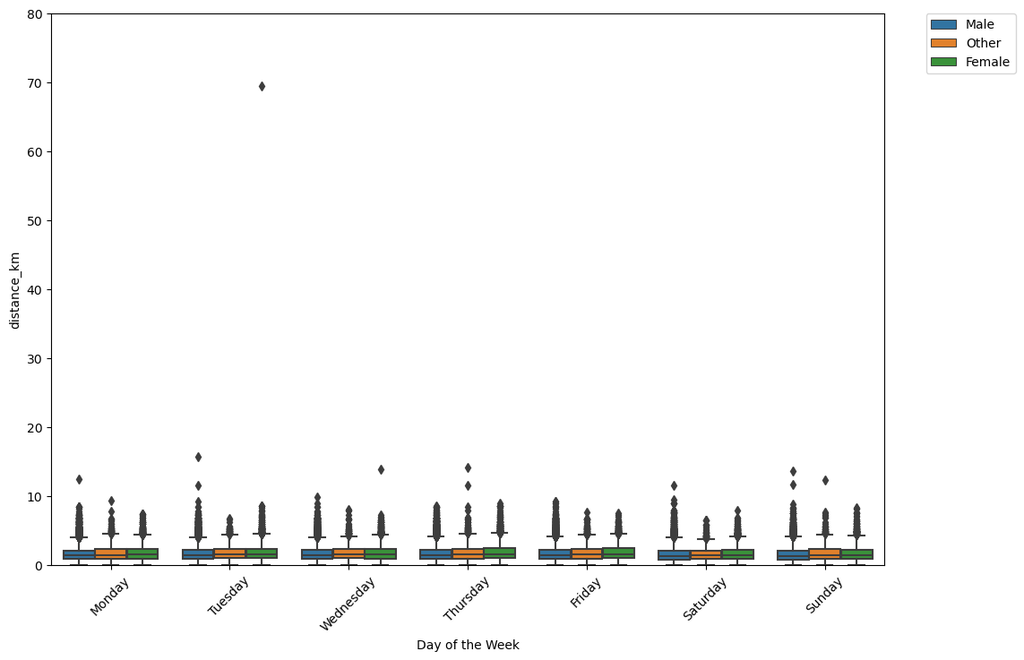

```
''
```

```python
plt.figure(figsize=(12,8))
sns.boxplot(x='pickup_day', y= 'distance_km', data=df2,hue='member_gender', order=days_order)
plt.ylim(0,80)
plt.xlabel('Day of the Week' )
plt.xticks(rotation=45)
plt.legend(bbox_to_anchor=(1.05, 1), loc=2, borderaxespad=0.)
plt.show()
;
```

**In this plot, I’ve broken the distance travelled, not only by day, but also by gender. According to this one female customer had travelled 70km during the day. While far from impossible, it seems odd to use a commuter bike to travel such a distance in one day.**

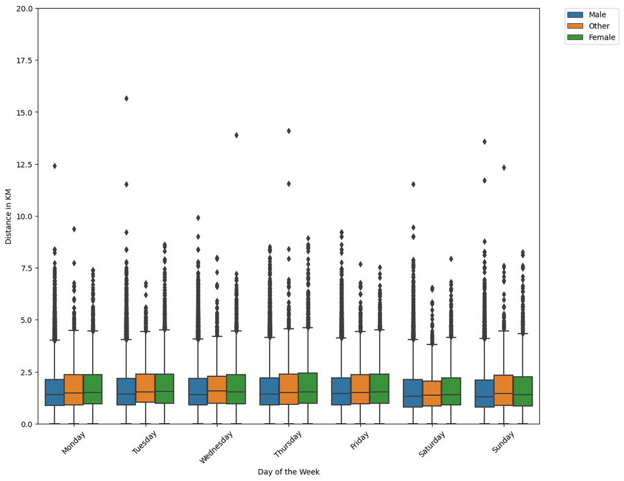

```
''
```

```python
# Pulling the average distance
av_distance = df2['distance_km'].mean()

# Filter the DataFrame to get the row(s) where 'distance_km' is equal to the mean value
av_distance_row = df2[df2['distance_km'] == av_distance]

# removing the 70K outlier
no_outlier = df2[df2['distance_km'] != av_distance]



plt.figure(figsize=(12,10))

new_av_distance = no_outlier['distance_miles'].mean()

sns.boxplot(x='pickup_day', y= 'distance_km', data=no_outlier,hue='member_gender', order=days_order)
plt.ylim(0,20)
plt.ylabel('Distance in KM')
plt.xlabel('Day of the Week' )
plt.xticks(rotation=45)
plt.legend(bbox_to_anchor=(1.05, 1), loc=2, borderaxespad=0.)
plt.show()
;
```

**This provides a more balanced look at the daily usage, it still skews male, but this may be due to the large number of male customers**

### Looking at Bike Shares by Gender and Distance Travelled

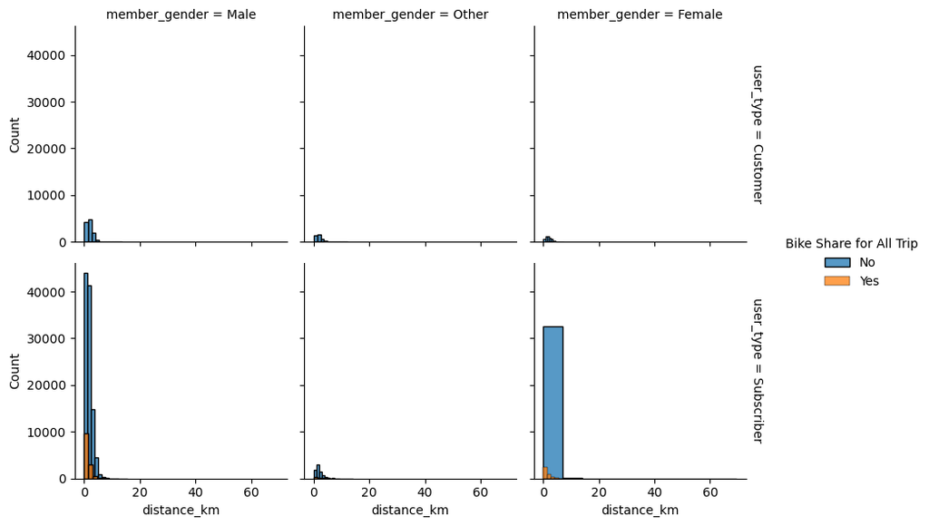

```python
# Convert 'NaN' strings to actual NaN values for proper handling
df2['member_gender'].replace('NaN', pd.NA, inplace=True)

# Convert inf values to NaN
df2.replace([np.inf, -np.inf], np.nan, inplace=True)

# FacetGrid
g = sns.FacetGrid(df2, row='user_type', col='member_gender', hue='bike_share_for_all_trip', margin_titles=True)
g.map(sns.histplot, 'distance_km', kde=False, bins=10)

# Add legends
g.add_legend(title='Bike Share for All Trip')

#
plt.show();
```

### Talk about some of the relationships you observed in this part of the investigation. Were there features that strengthened each other in terms of looking at your feature(s) of interest?

**There appears to be fewer customers vs subscribers across all available genders. This is great for the company as it shows that there is a clear demand for regular use of their service.**

### Were there any interesting or surprising interactions between features?

**This is interesting, as the data has already shown, there are fewer female customers (compared to males) however there’s not that much difference between them in terms of user type (Customer vs Subscriber). And it looks like, for the most part, that most of the usage of the bikes aren't "Bike Share", again, this makes sense if the majority of the rides are used to commute to and from work**

## Conclusions

In conclusion, for me, the biggest surprise was the split in gender. Some customer/non customer feedback might shed some light as to why this is. Factors might include: Not feeling safe riding on the road, the cost and/or weight of the bike or they may already have their own bikes. Once they have this info they could make adjustments to get more people riding.

Also trying to find out why over 8000 customers, most of which are subscribers, were reluctant to add more personal data. This strikes me as very strange because if you’re a subscriber then one would assume that you would pay via your bank and to ensure that there’s no fraudulent activity on the account, you would have to enter all of the valid information, such as D.O.B. But I haven’t seen the signup form and things might like this might operate differently in the US than they do in R.o.t.W.

This could be an issue of trust which should be, if true, looked into.

df2.to_csv('fordgobike_feb_data_clean.csv')